# Preliminary Report April 3

Joey

2025-04-04

# Introduction

## Analysis Objectives

The preliminary analysis will identify and count the number of PCR positives for each virus tested (COVID-19, Influenza A, Influenza B, and RSV). We will also create a variable for symptom duration, defined as the difference between symptom onset and the visit date. We used the visit date and patient reported recent vaccination date for the COVID vaccine, the Omicron Booster, and the Flu vaccine to stratify by time since vaccination. First we will plot the PCR Ct values, which is a surrogate for viral load, from the positive individuals by days of symptom duration. Future analyses will include the time since vaccination variables.

# Descriptive Analyses of RADX Data

## Table 1

Characteristics of 1462 participants are displayed in the table below.

| **Characteristic** | **N = 1,462**<sup>1</sup> |
| --- | --- |
| COVID-19 PCR Test Result |  |
| Negative | 1,154 (79%) |
| Positive | 308 (21%) |
| Not Determined | 0 (0%) |
| Flu A PCR Test Result |  |
| Negative | 1,283 (88%) |
| Positive | 173 (12%) |
| Not Determined | 0 (0%) |
| Unknown | 6 |
| Flu B PCR Test Result |  |
| Negative | 1,388 (95%) |
| Positive | 68 (4.7%) |
| Not Determined | 0 (0%) |
| Unknown | 6 |
| RSV PCR Test Result |  |
| Negative | 1,399 (96%) |
| Positive | 55 (3.8%) |
| Not Determined | 0 (0%) |
| Unknown | 8 |
| Vaccination for COVID-19 |  |
| No | 382 (36%) |
| Yes | 674 (64%) |
| Unknown/No Response | 0 (0%) |
| Unknown | 406 |
| Duration since Symptom Onset |  |
| 0 Days | 5 (8.3%) |
| 1 day | 8 (13%) |
| 2 days | 12 (20%) |
| 3 days | 6 (10%) |
| 4 days | 11 (18%) |
| 5 days | 11 (18%) |
| 6 days | 7 (12%) |
| Unknown | 1,402 |
| Duration since most recent COVID Vaccine |  |
| Less than 3 months | 16 (2.5%) |
| 3-6 months | 23 (3.6%) |
| 6-9 months | 21 (3.3%) |
| 9-12 months | 13 (2.0%) |
| 12-18 months | 108 (17%) |
| 18-24 months | 89 (14%) |
| Over two years | 366 (58%) |
| Unknown | 826 |
| Duration since Omicron Booster |  |
| Less than 3 months | 0 (0%) |
| 3-6 months | 3 (3.7%) |
| 6-9 months | 3 (3.7%) |
| 9-12 months | 7 (8.5%) |
| 12-18 months | 19 (23%) |
| 18-24 months | 18 (22%) |
| Over two years | 32 (39%) |
| Unknown | 1,380 |
| Duration since most recent Flu Vaccine |  |
| Less than 3 months | 30 (12%) |
| 3-6 months | 47 (19%) |
| 6-9 months | 13 (5.3%) |
| 9-12 months | 29 (12%) |
| 12-18 months | 99 (41%) |
| 18-24 months | 8 (3.3%) |
| Over two years | 17 (7.0%) |
| Unknown | 1,219 |

<sup>1</sup> n (%)

## COVID-19

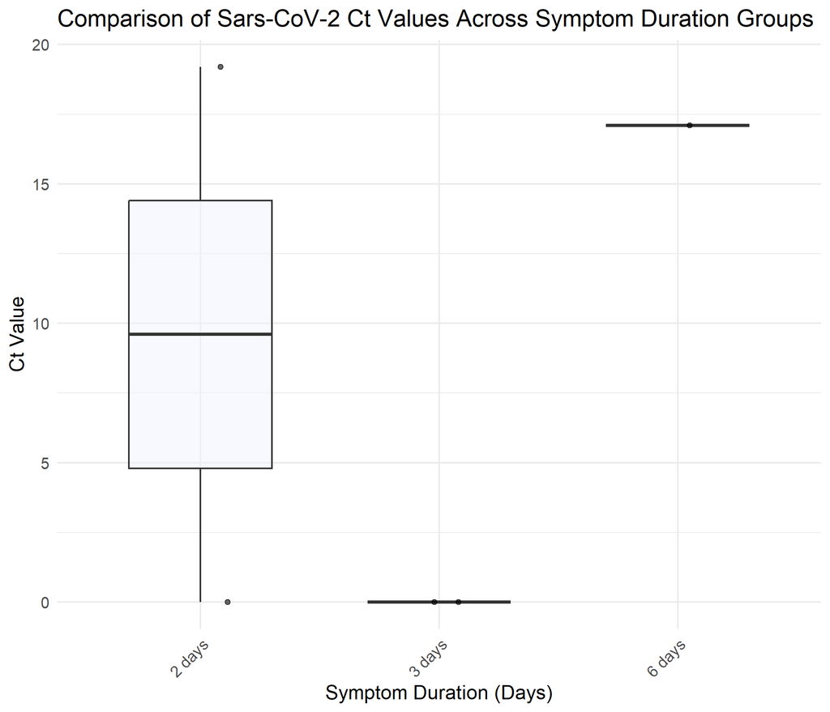

There were 308 PCR Positives for Sars-CoV-2. Of these, 95 had Ct values reported in their chart. Above is a figure of Ct Values by days of symptom duration.

## Flu A

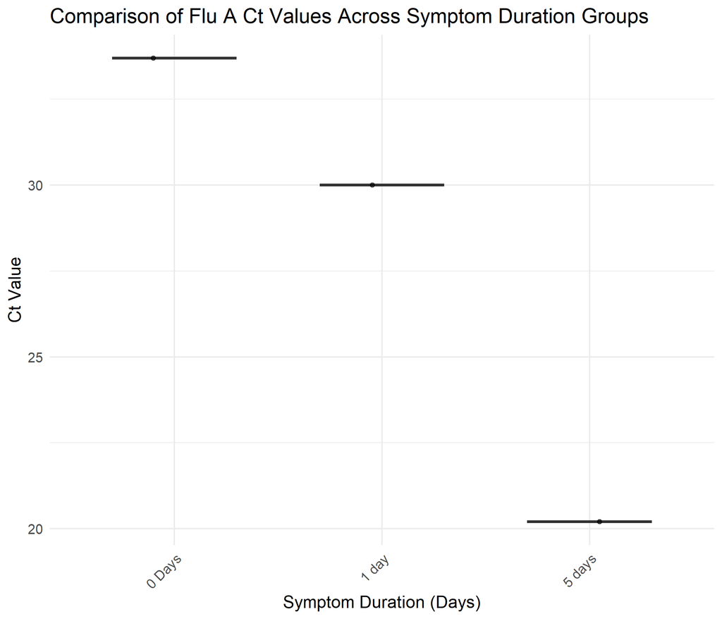

There were 173 PCR Positives for Influenza A. Of these, 19 had Ct values reported in their chart. Above is a figure of Ct Values by days of symptom duration.

## Flu B

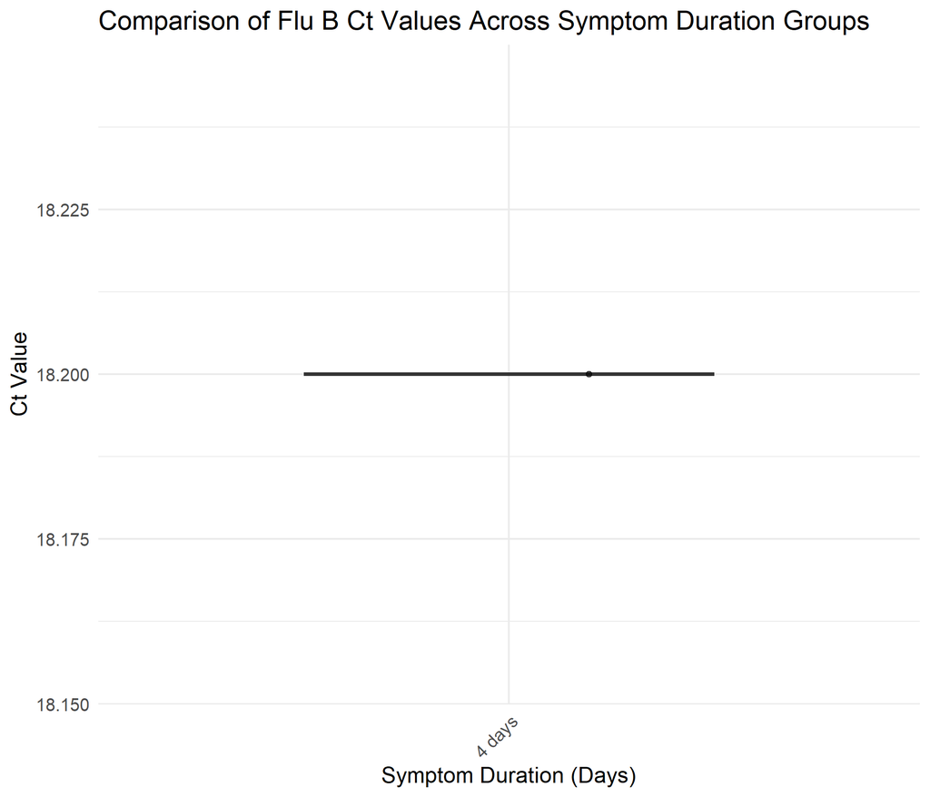

There were 68 PCR Positives for Influenza B. Of these, 6 had Ct values reported in their chart. Above is a figure of Ct Values by days of symptom duration.

## RSV

[figure not shown]